# Midterm1

Rabin Paudel

9/30/2021

### Honor pledge

#### Signature: Rabin Paudel

## Problem I (20pts)

```r
library(babynames)
library(mdsr)
names_df <- make_babynames_dist()
names_df
```

```
## # A tibble: 1,639,722 x 9
##     year sex   name          n   prop alive_prob count_thousands age_today
##    <dbl> <chr> <chr>     <int>  <dbl>      <dbl>           <dbl>     <dbl>
##  1  1900 F     Mary      16706 0.0526          0           16.7        114
##  2  1900 F     Helen      6343 0.0200          0            6.34       114
##  3  1900 F     Anna       6114 0.0192          0            6.11       114
##  4  1900 F     Margaret   5304 0.0167          0            5.30       114
##  5  1900 F     Ruth       4765 0.0150          0            4.76       114
##  6  1900 F     Elizabeth  4096 0.0129          0            4.10       114
##  7  1900 F     Florence   3920 0.0123          0            3.92       114
##  8  1900 F     Ethel      3896 0.0123          0            3.90       114
##  9  1900 F     Marie      3856 0.0121          0            3.86       114
## 10  1900 F     Lillian    3414 0.0107          0            3.41       114
## # … with 1,639,712 more rows, and 1 more variable: est_alive_today <dbl>
```

#### The Hmisc library is useful to get the wtd.quantile function to compute the

#### weighted quantile for the age distribution below

```r
library(Hmisc)
library(dplyr)
library(tidyr)
names_age_dist <- names_df %>%
filter(n > 100) %>%
group_by(name,sex) %>%
mutate(wgt = est_alive_today / sum(est_alive_today)) %>%
dplyr::summarize(
N = n(),
est_num_alive = sum(est_alive_today),
quantiles = list(
wtd.quantile(
age_today, est_alive_today, probs = c(0.25, 0.5, 0.75), na.rm = TRUE
)
)
) %>%
mutate(measures = list(c("q1_age", "median_age", "q3_age"))) %>%
unnest(cols = c(quantiles, measures)) %>%
pivot_wider(names_from = measures, values_from = quantiles) %>% ungroup()
names_age_dist
```

```
## # A tibble: 6,889 x 7
##    name    sex       N est_num_alive q1_age median_age q3_age
##    <chr>   <chr> <int>         <dbl>  <dbl>      <dbl>  <dbl>
##  1 Aaden   M         4         2810.    5         5         6
##  2 Aaliyah F        17        48409.    6        10        13
##  3 Aaniyah F         2          206.    6         6.66      8
##  4 Aanya   F         4          709.    4         5         6
##  5 Aaralyn F         1          134.    8         8         8
##  6 Aarav   M         5         1223.    4         5         6
##  7 Aaron   F        17         2313.   27.0      32        35
##  8 Aaron   M       106       488210.   17        26        36
##  9 Aarush  M         4          620.    4         5         6
## 10 Aayan   M         2          216.    5         5         7
## # … with 6,879 more rows
```

```r
names_max_iqr <- names_age_dist %>% mutate(iqr = q3_age - q1_age) %>%
filter(N >= 100) %>% group_by(sex) %>%
slice_max(iqr,n=10)
names_max_iqr
```

```
## # A tibble: 21 x 8
## # Groups:   sex [2]
##    name      sex       N est_num_alive q1_age median_age q3_age   iqr
##    <chr>     <chr> <int>         <dbl>  <dbl>      <dbl>  <dbl> <dbl>
##  1 Violet    F       111        42347.     10         62     81    71
##  2 Lila      F       110        29913.      8         46     73    65
##  3 Lillian   F       111       160554.     10         48     75    65
##  4 Stella    F       111        55076.     11         57     73    62
##  5 Genevieve F       111        42609.     17         42     77    60
##  6 Lucy      F       111        83295.     12         51     70    58
##  7 Angeline  F       109        15185.     19         44     76    57
##  8 Jewel     F       107        19430.     17         55     74    57
##  9 Cora      F       111        41809.     18         58     74    56
## 10 Ella      F       111       129546.      7         11     63    56
## # … with 11 more rows
```

#### Using this data, generate the following similar figure.

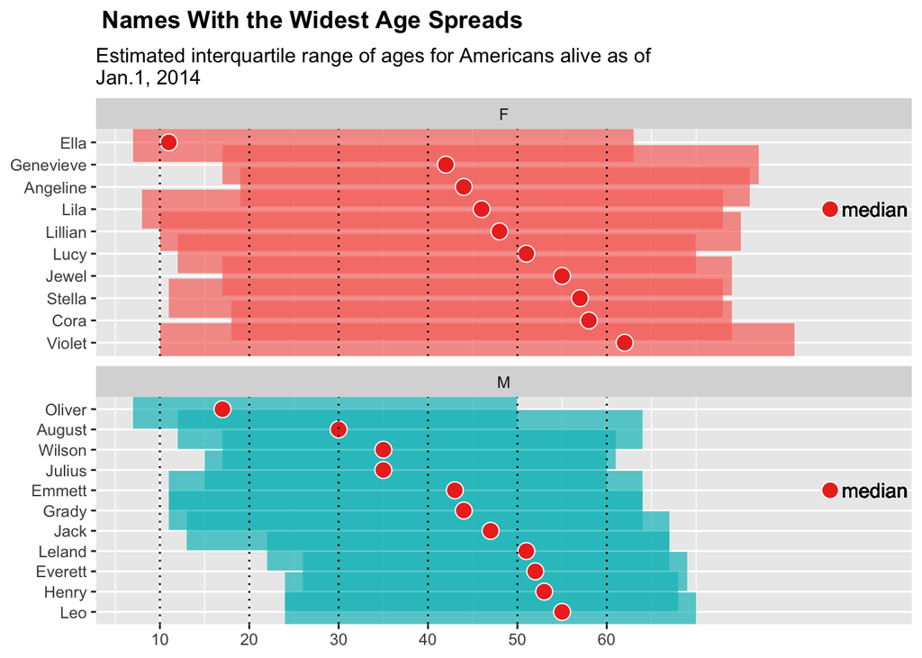

```r
age_breaks <- head(1:8 * 10 + 0)

p0 <- ggplot(data = names_max_iqr,
             aes(x = reorder(name, -median_age)), y = median_age)+ xlab(NULL) +
  ylab(NULL) + ggtitle(~bold("Names With the Widest Age Spreads"),
subtitle = "Estimated interquartile range of ages for Americans alive as of
Jan.1, 2014")
p1 <-  p0 + geom_linerange(aes(ymin = q1_age, ymax = q3_age, color = sex),
                           size = 10, alpha = 0.7, show.legend = NULL)

p2 <- p1 + scale_y_continuous(breaks = age_breaks)+
  geom_point(aes(x = 7, y = 85), fill = "#ed3324",
             color = "white", size = 4, shape = 21) +
  geom_point(aes(y = median_age), fill = "#ed3324",
             color = "white", size = 4, shape = 21) +
  geom_text(aes(y = 90, x = 7, label = "median"))

p3 <- p2 + facet_wrap(~sex, nrow=2, scales = "free_y") + geom_hline(
  data = tibble(x = age_breaks),
  aes(yintercept = x),
  linetype = 3
) +
  coord_flip()
p3
```

## Problem II (20pts)

#### The next problem uses the weather dataframe from the nycflights13 library.

```r
library(nycflights13)
library(dplyr)
weather
```

```
## # A tibble: 26,115 x 15
##    origin  year month   day  hour  temp  dewp humid wind_dir wind_speed
##    <chr>  <int> <int> <int> <int> <dbl> <dbl> <dbl>    <dbl>      <dbl>
##  1 EWR     2013     1     1     1  39.0  26.1  59.4      270      10.4
##  2 EWR     2013     1     1     2  39.0  27.0  61.6      250       8.06
##  3 EWR     2013     1     1     3  39.0  28.0  64.4      240      11.5
##  4 EWR     2013     1     1     4  39.9  28.0  62.2      250      12.7
##  5 EWR     2013     1     1     5  39.0  28.0  64.4      260      12.7
##  6 EWR     2013     1     1     6  37.9  28.0  67.2      240      11.5
##  7 EWR     2013     1     1     7  39.0  28.0  64.4      240      15.0
##  8 EWR     2013     1     1     8  39.9  28.0  62.2      250      10.4
##  9 EWR     2013     1     1     9  39.9  28.0  62.2      260      15.0
## 10 EWR     2013     1     1    10  41    28.0  59.6      260      13.8
## # … with 26,105 more rows, and 5 more variables: wind_gust <dbl>, precip <dbl>,
## #   pressure <dbl>, visib <dbl>, time_hour <dttm>
```

### (a) The ten most rainy day in the NYC metro area in 2013.

```r
weather %>% group_by(origin, year, month, day) %>% summarise(precip) %>%
arrange(desc(precip))%>%
head(10)
```

```
## # A tibble: 10 x 5
## # Groups:   origin, year, month, day [10]
##    origin  year month   day precip
##    <chr>  <int> <int> <int>  <dbl>
##  1 EWR     2013     8    28   1.21
##  2 EWR     2013     6     2   1.06
##  3 EWR     2013     7     3   0.94
##  4 LGA     2013     9     2   0.82
##  5 LGA     2013     9    12   0.68
##  6 JFK     2013     9    22   0.66
##  7 LGA     2013     6     8   0.66
##  8 JFK     2013     7     1   0.65
##  9 LGA     2013     5     8   0.64
## 10 JFK     2013     5     8   0.58
```

### (b) To find three consecutive days in 2013 where the highest temp. is at

### least 95 degrees Farenheit.

```r
new <- weather %>% filter(origin == "JFK") %>% group_by(year,month,day) %>%
  summarise(max_temp = max(temp)) %>% ungroup()
new %>% arrange(year, month, day) %>% filter(lag(max_temp) > 95)
```

```
## # A tibble: 2 x 4
##    year month   day max_temp
##   <int> <int> <int>    <dbl>
## 1  2013     7    17     95
## 2  2013     7    19     93.9
```

### (c) Find the dates and time of the ten observations with the largest

### temperature difference between the three airports

```r
library(nycflights13)
library(dplyr)
library(tidyr)
weather_subset <- weather %>% select(origin,year,month,day,hour,temp)
weather_temp_wide <- weather_subset %>% group_by(origin,year,month,day,hour) %>%
dplyr::summarize(temp = mean(temp)) %>%
pivot_wider(names_from = "origin", values_from = "temp") %>% ungroup()
weather_temp_wide
```

```
## # A tibble: 8,713 x 7
##     year month   day  hour   EWR   JFK   LGA
##    <int> <int> <int> <int> <dbl> <dbl> <dbl>
##  1  2013     1     1     1  39.0  39.0  39.9
##  2  2013     1     1     2  39.0  39.0  41
##  3  2013     1     1     3  39.0  39.9  41
##  4  2013     1     1     4  39.9  39.9  41
##  5  2013     1     1     5  39.0  39.0  39.9
##  6  2013     1     1     6  37.9  37.9  39.9
##  7  2013     1     1     7  39.0  39.0  39.9
##  8  2013     1     1     8  39.9  39.9  39.9
##  9  2013     1     1     9  39.9  39.9  39.9
## 10  2013     1     1    10  41    41    39.9
## # … with 8,703 more rows
```

#### The largest temperture difference are.

```r
weather_temp_wide %>% mutate(temp_diff = pmax(EWR, JFK, LGA) -
                               pmin(EWR,JFK,LGA)) %>%
  arrange(desc(temp_diff)) %>% head(10)
```

```
## # A tibble: 10 x 8
##     year month   day  hour   EWR   JFK   LGA temp_diff
##    <int> <int> <int> <int> <dbl> <dbl> <dbl>     <dbl>
##  1  2013     5     8    22  59    13.1  59        45.9
##  2  2013     5    30    20  87.1  64.9  88.0      23.0
##  3  2013     5    30    22  84.0  64.0  86        22.0
##  4  2013     5    30    19  89.1  68    86        21.1
##  5  2013     5    30    21  84.0  66.0  87.1      21.1
##  6  2013     5    31    18  91.0  71.1  84.9      20.0
##  7  2013     6     2    18  84.9  66.0  86        20.0
##  8  2013     5    29    18  87.1  68    79.0      19.1
##  9  2013     6     2    16  89.1  70.0  84.0      19.1
## 10  2013     6     2    20  84.0  64.9  79.0      19.1
```

## Problem III(20pts)

#### This problem uses data on song rankings for billboard top 100 in the years

#### 2000. A snippet of the data is given below.

```r
library(tidyr)
billboard
```

```
## # A tibble: 317 x 79
##    artist   track   date.entered   wk1   wk2   wk3   wk4   wk5   wk6   wk7   wk8
##    <chr>    <chr>   <date>       <dbl> <dbl> <dbl> <dbl> <dbl> <dbl> <dbl> <dbl>
##  1 2 Pac    Baby D… 2000-02-26      87    82    72    77    87    94    99    NA
##  2 2Ge+her  The Ha… 2000-09-02      91    87    92    NA    NA    NA    NA    NA
##  3 3 Doors… Krypto… 2000-04-08      81    70    68    67    66    57    54    53
##  4 3 Doors… Loser   2000-10-21      76    76    72    69    67    65    55    59
##  5 504 Boyz Wobble… 2000-04-15      57    34    25    17    17    31    36    49
##  6 98^0     Give M… 2000-08-19      51    39    34    26    26    19     2     2
##  7 A*Teens  Dancin… 2000-07-08      97    97    96    95   100    NA    NA    NA
##  8 Aaliyah  I Don'… 2000-01-29      84    62    51    41    38    35    35    38
##  9 Aaliyah  Try Ag… 2000-03-18      59    53    38    28    21    18    16    14
## 10 Adams, … Open M… 2000-08-26      76    76    74    69    68    67    61    58
## # … with 307 more rows, and 68 more variables: wk9 <dbl>, wk10 <dbl>,
## #   wk11 <dbl>, wk12 <dbl>, wk13 <dbl>, wk14 <dbl>, wk15 <dbl>, wk16 <dbl>,
## #   wk17 <dbl>, wk18 <dbl>, wk19 <dbl>, wk20 <dbl>, wk21 <dbl>, wk22 <dbl>,
## #   wk23 <dbl>, wk24 <dbl>, wk25 <dbl>, wk26 <dbl>, wk27 <dbl>, wk28 <dbl>,
## #   wk29 <dbl>, wk30 <dbl>, wk31 <dbl>, wk32 <dbl>, wk33 <dbl>, wk34 <dbl>,
## #   wk35 <dbl>, wk36 <dbl>, wk37 <dbl>, wk38 <dbl>, wk39 <dbl>, wk40 <dbl>,
## #   wk41 <dbl>, wk42 <dbl>, wk43 <dbl>, wk44 <dbl>, wk45 <dbl>, wk46 <dbl>,
## #   wk47 <dbl>, wk48 <dbl>, wk49 <dbl>, wk50 <dbl>, wk51 <dbl>, wk52 <dbl>,
## #   wk53 <dbl>, wk54 <dbl>, wk55 <dbl>, wk56 <dbl>, wk57 <dbl>, wk58 <dbl>,
## #   wk59 <dbl>, wk60 <dbl>, wk61 <dbl>, wk62 <dbl>, wk63 <dbl>, wk64 <dbl>,
## #   wk65 <dbl>, wk66 <lgl>, wk67 <lgl>, wk68 <lgl>, wk69 <lgl>, wk70 <lgl>,
## #   wk71 <lgl>, wk72 <lgl>, wk73 <lgl>, wk74 <lgl>, wk75 <lgl>, wk76 <lgl>
```

#### Using this data, write code to convert the data into a long format similar

#### to the one below.

```r
cd <- billboard  %>% pivot_longer(cols = starts_with("wk"), names_to = "week",
                                   values_to = "rank", values_drop_na = TRUE)
cd %>% mutate(week = as.numeric(gsub("wk", "", week)))
```

```
## # A tibble: 5,307 x 5
##    artist  track                   date.entered  week  rank
##    <chr>   <chr>                   <date>       <dbl> <dbl>
##  1 2 Pac   Baby Don't Cry (Keep... 2000-02-26       1    87
##  2 2 Pac   Baby Don't Cry (Keep... 2000-02-26       2    82
##  3 2 Pac   Baby Don't Cry (Keep... 2000-02-26       3    72
##  4 2 Pac   Baby Don't Cry (Keep... 2000-02-26       4    77
##  5 2 Pac   Baby Don't Cry (Keep... 2000-02-26       5    87
##  6 2 Pac   Baby Don't Cry (Keep... 2000-02-26       6    94
##  7 2 Pac   Baby Don't Cry (Keep... 2000-02-26       7    99
##  8 2Ge+her The Hardest Part Of ... 2000-09-02       1    91
##  9 2Ge+her The Hardest Part Of ... 2000-09-02       2    87
## 10 2Ge+her The Hardest Part Of ... 2000-09-02       3    92
## # … with 5,297 more rows
```

## Problem IV(30pts)

#### The data is part of the fec16 library. Please refer to the given link for

#### more details about the data.

```r
## First do an install.packages("fec16") if the fec16 library is missing.
library(fec16)
## If you are using Rmarkdown you might want to run this chunk only once
## or set the chunk option cache=TRUE
## so as to not download the data again and again and again
all_contributions <- read_all_contributions()
```

```
## ✓ Downloading from 'https://www.fec.gov/files/bulk-downloads/2016/pas216.zip'
```

```
## ✓ Download stored in '/var/folders/n6/73h2lv1n60l1hyb8sbv_d0yr0000gn/T/Rtmp7QwulA/pas216.zip'
```

```
## ✓ Unpacking ZIP file into 'pas216/' (1 files extracted)
```

```
## ✓ Deleting 'pas216.zip'
```

```r
all_contributions
```

```
## # A tibble: 516,394 x 15
##    cmte_id amndt_ind rpt_tp transaction_pgi transaction_tp entity_tp name  city
##    <chr>   <chr>     <chr>  <chr>           <chr>          <chr>     <chr> <chr>
##  1 C00548… N         M3     G2016           24K            CCM       BLAI… JEFF…
##  2 C00235… N         M3     P2014           24K            CCM       DAN … YAKI…
##  3 C00235… N         M3     P2016           24K            CCM       CATH… SPOK…
##  4 C00235… N         M3     G2018           24K            CCM       MANC… WASH…
##  5 C00235… N         M3     P2016           24K            CCM       PETE… WASH…
##  6 C00548… N         M3     G2016           24K            CCM       KEVI… BAKE…
##  7 C00235… N         M3     P2016           24K            CCM       ALAN… WASH…
##  8 C00235… N         M3     G2016           24K            CCM       BLUM… STAM…
##  9 C00235… N         M3     G2016           24K            CCM       GEOR… WASH…
## 10 C00235… N         M3     P2016           24K            CCM       FRIE… EAST…
## # … with 516,384 more rows, and 7 more variables: state <chr>, zip_code <chr>,
## #   transaction_dt <date>, transaction_amt <dbl>, other_id <chr>,
## #   cand_id <chr>, tran_id <chr>
```

### a. (10pts)

#### incumbent candidates who lost.

```r
newData <- candidates %>% left_join(results_senate, by = "cand_id") %>%
   filter(cand_ici == "C", won == "TRUE") %>% summarise(cand_name)
newData
```

```
## # A tibble: 2 x 1
##   cand_name
##   <chr>
## 1 DUCKWORTH, L TAMMY
## 2 HASSAN, MARGARET WOOD
```

### b. (10pts)

#### Draw a scatterplot visualizing the relationship between the total amount of

#### contributions a candidate received and the number of votes they got in

#### the US senate elections

```r
result <- left_join(results_senate, candidates, by = "cand_id") %>%
  left_join(all_contributions, by = "cand_id") %>%
  group_by(cand_id, cand_name, cand_pty_affiliation) %>%
  summarise(
    sum_votes = sum(general_votes, na.rm = TRUE),
    contribution = sum(transaction_amt, na.rm = TRUE)
  ) %>% filter(sum_votes>10)
head(result)
```

```
## # A tibble: 6 x 5
## # Groups:   cand_id, cand_name [6]
##   cand_id   cand_name           cand_pty_affiliation   sum_votes contribution
##   <chr>     <chr>               <chr>                      <dbl>        <dbl>
## 1 S0AK00121 MILLER, JOSEPH W    LIB                       544950        17929
## 2 S0AR00150 BOOZMAN, JOHN       REP                    603067424      2093385
## 3 S0CO00211 BENNET, MICHAEL F   DEM                   2426156700      4936351
## 4 S0CT00177 BLUMENTHAL, RICHARD DEM                    858415614      3363730
## 5 S0CT00250 RUSSELL, JEFF       GRE                        16713            0
## 6 S0FL00338 RUBIO, MARCO        REP                  12145999792     15781887
```

```r
result
```

```
## # A tibble: 177 x 5
## # Groups:   cand_id, cand_name [177]
##    cand_id   cand_name               cand_pty_affiliati…  sum_votes contribution
##    <chr>     <chr>                   <chr>                    <dbl>        <dbl>
##  1 S0AK00121 MILLER, JOSEPH W        LIB                    5.45e 5        17929
##  2 S0AR00150 BOOZMAN, JOHN           REP                    6.03e 8      2093385
##  3 S0CO00211 BENNET, MICHAEL F       DEM                    2.43e 9      4936351
##  4 S0CT00177 BLUMENTHAL, RICHARD     DEM                    8.58e 8      3363730
##  5 S0CT00250 RUSSELL, JEFF           GRE                    1.67e 4            0
##  6 S0FL00338 RUBIO, MARCO            REP                    1.21e10     15781887
##  7 S0FL00544 KNEPPER, HOWARD         REP                    5   e 1            0
##  8 S0HI00126 CARROLL, JOHN STANLEY   REP                    3.71e 5         1744
##  9 S0IA00028 GRASSLEY, CHARLES E SE… REP                    1.28e 9      3032869
## 10 S0IL00261 KIRK, MARK STEVEN       REP                    5.18e 9      5269556
## # … with 167 more rows
```

#### Draw a scatterplot and visualizing the data.

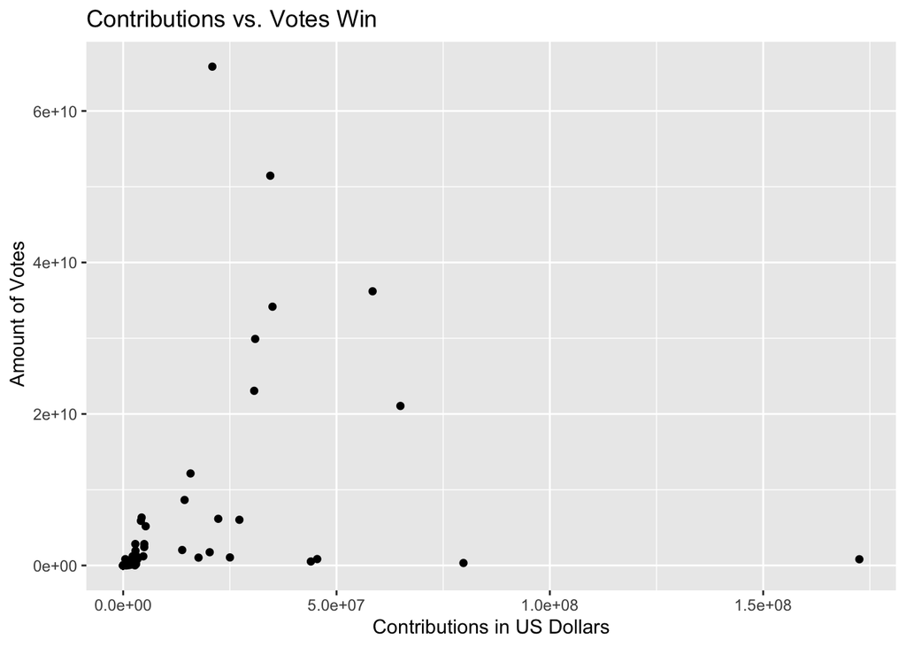

```r
ggplot(result) + geom_point(aes(x = contribution, y = sum_votes))+
  labs(
    title = "Contributions vs. Votes Win",
    x = "Contributions in US Dollars", y = " Amount of Votes"
  )
```

### c. (10pts)

#### The type of interest group for each committee is recorded as part of the

#### org_tp variable in the commitees data frame. For example.

```r
library(fec16)
committees %>% select(org_tp) %>% pull %>% table(useNA = "always")
```

```
## .
##     C     H     I     L     M     T     V     W  <NA>
##  1811     9     4   397   524   747    45   105 14012
```

#### You might need the candidate id for the two candidates Hillary Clinton

#### and Donald Trump. You can do so using the following code chunk example.

```r
## You might need to first do an install.packages("stringr")
## if the stringr library cannot be loaded.
candidates %>% filter(stringr::str_detect(cand_name, "CLINTON"))
```

```
## # A tibble: 2 x 15
##   cand_id cand_name cand_pty_affili… cand_election_yr cand_office_st cand_office
##   <chr>   <chr>     <chr>                       <dbl> <chr>          <chr>
## 1 P00003… CLINTON,… DEM                          2016 US             P
## 2 P60012… CLINTON,… DFL                          2016 US             P
## # … with 9 more variables: cand_office_district <chr>, cand_ici <chr>,
## #   cand_status <chr>, cand_pcc <chr>, cand_st1 <chr>, cand_st2 <chr>,
## #   cand_city <chr>, cand_st <chr>, cand_zip <chr>
```

```r
candidates %>% filter(stringr::str_detect(cand_name, "TRUMP"))
```

```
## # A tibble: 3 x 15
##   cand_id cand_name cand_pty_affili… cand_election_yr cand_office_st cand_office
##   <chr>   <chr>     <chr>                       <dbl> <chr>          <chr>
## 1 P60018… "TRUMP, … REP                          2016 US             P
## 2 P60018… "TRUMP, … COM                          2016 US             P
## 3 P80001… "TRUMP, … REP                          2016 US             P
## # … with 9 more variables: cand_office_district <chr>, cand_ici <chr>,
## #   cand_status <chr>, cand_pcc <chr>, cand_st1 <chr>, cand_st2 <chr>,
## #   cand_city <chr>, cand_st <chr>, cand_zip <chr>
```

#### Only two committees L,C for CLINTON.

```r
join <- left_join(contributions, candidates, by = "cand_id") %>%
  filter( cand_id == "P00003392" |cand_id == "P60012333") %>%
  summarise(cmte_id, transaction_amt, cand_id) %>%
  left_join(committees, by = "cmte_id") %>%
  select(transaction_amt, org_tp) %>% filter(org_tp != "NA") %>%
  arrange(desc(org_tp))
join
```

```
## # A tibble: 5 x 2
##   transaction_amt org_tp
##             <dbl> <chr>
## 1           23116 L
## 2             193 L
## 3            7391 L
## 4              13 L
## 5            1000 C
```

#### Only one committees M for TRUMP.

```r
join1 <- left_join(contributions, candidates, by = "cand_id") %>%
  filter( cand_id == "P60018835" |cand_id == "P60018991" | cand_id == "P80001571") %>%
  summarise(cmte_id, transaction_amt, cand_id) %>%
  left_join(committees, by = "cmte_id") %>%
  select(transaction_amt, org_tp) %>% filter(org_tp != "NA") %>%
  arrange(desc(org_tp))
join1
```

```
## # A tibble: 2 x 2
##   transaction_amt org_tp
##             <dbl> <chr>
## 1             941 M
## 2           50000 M
```